# Design PNAs for crop plants

Briana K. Whitaker

2022-10-07

- Run using R version 4.2.1 (2022-06-23 ucrt).

# Objective

Goal: Find PNA candidates that block plant ITS amplification, within the context of the fITS7-ITS4ngs primer spanning region. Species of interest: Triticum aestivum (i.e., WHT), Glycine max (i.e., SOY), Hordeum vulgare (i.e. BAR), & (Maybe) Zea mays (i.e., CRN).

# Plant DNA Templates

- Genome blast hits

```r
Ta.SS.hits <- readDNAStringSet("./data/Taestivum_IWGSC_v2.1__queryTa_KY437101.1-MN787127.1_filtered.fasta")
Zm.SS.hits <- readDNAStringSet("./data/Zmays_493_APGv4__queryZm_EU955045.1_filtered.fasta")
Hv.SS.hits <- readDNAStringSet("./data/Hvulgare_462_r1__queryHv_ncbi_consensus_filtered.fasta")
Gm.SS.hits <- readDNAStringSet("./data/Gmax_508_v4__queryGm_ncbi_consensus_filtered-2divergentSeqs.fasta")
```

- Of these alignments, only the Gm looks reasonably constant across the breadth of the ITS.

### ASVs from previous sequencing runs

```r
Ta.asvs1 <- readDNAStringSet("./data/ASVs/Ta_ASVs_ITS1.fasta") #26
Zm.asvs1 <- readDNAStringSet("./data/ASVs/Zm_ASVs_ITS1.fasta") #10
Gm.asvs1 <- readDNAStringSet("./data/ASVs/Gm_ASVs_ITS1.fasta") #7

Ta.asvs2 <- readDNAStringSet("./data/ASVs/Ta_ASVs_ITS2.fasta") #29
Zm.asvs2 <- readDNAStringSet("./data/ASVs/Zm_ASVs_ITS2.fasta") #3
Hv.asvs2 <- readDNAStringSet("./data/ASVs/Hv_ASVs_ITS2.fasta") #8
Gm.asvs2 <- readDNAStringSet("./data/ASVs/Gm_ASVs_ITS2.fasta") #1

#Note - Ta_ASVs_ITS2_aln.fasta has 3 ASVs that are very very divergent from the rest
  # ASV 227 226 130 from the Sept Nano run of ITS2 region, will remove and realign
#Note - Zm_ASVs_ITS1_aln.fasta has 3 ASVs with weirdly very long gaps in their alignment. Will leave for now, since ITS1 not main focus.
```

### primers

```r
fITS7   <- DNAString("GTGARTCATCGAATCTTTG")
ITS4ngs <- DNAString("TCCTSCGCTTATTGATATGC")

fITS7.rc <- reverseComplement(fITS7)
ITS4ngs.rc <- reverseComplement(ITS4ngs)


fITS7; fITS7.rc
```

```
## 19-letter DNAString object
## seq: GTGARTCATCGAATCTTTG
```

```
## 19-letter DNAString object
## seq: CAAAGATTCGATGAYTCAC
```

```r
ITS4ngs; ITS4ngs.rc
```

```
## 20-letter DNAString object
## seq: TCCTSCGCTTATTGATATGC
```

```
## 20-letter DNAString object
## seq: GCATATCAATAAGCGSAGGA
```

# Visualize alignment of plant ASVs

- Aligned plant ASVs usingMAFFT-LINSI on ceres.
- The visualization of the alignment is below, focusing on the full alignment.

### Ta

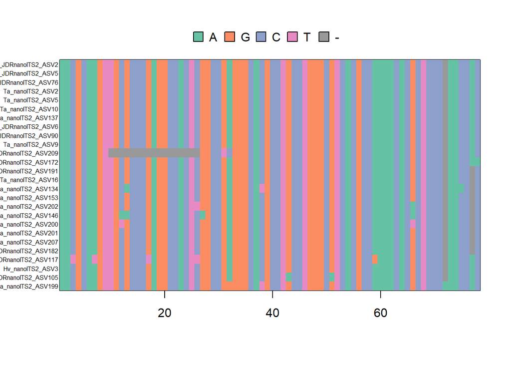

- based on comparing Ta alignment of blasted ITS from Ta genome (Geneious), these ASVs are already forward oriented from the 5.8S to the LSU

### Hv

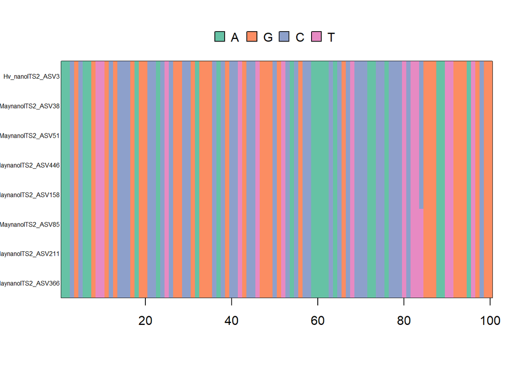

- based on comparing Hv alignment of blasted ITS from Hv genome (Geneious), these ASVs are already forward oriented from the 5.8S to the LSU

### Zm

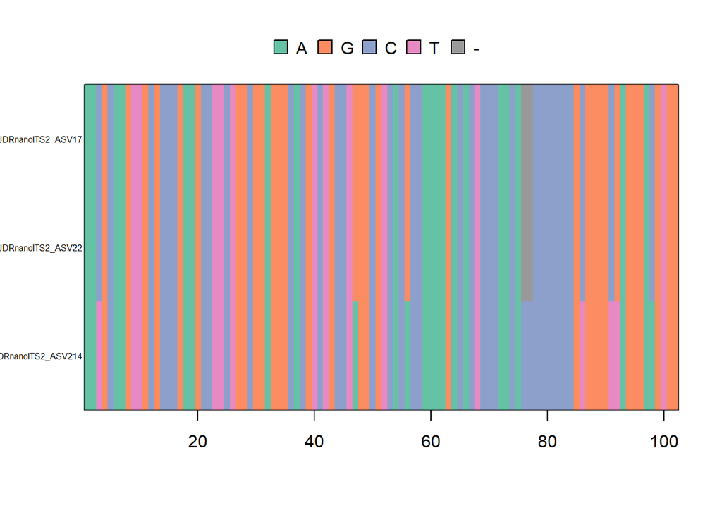

- based on comparing Zm alignment of blasted ITS from Zm genome (Geneious), these ASVs are already forward oriented from the 5.8S to the LSU.
- Note: thes ASVs match up with 5.8S-fun primer as forward

### Gm

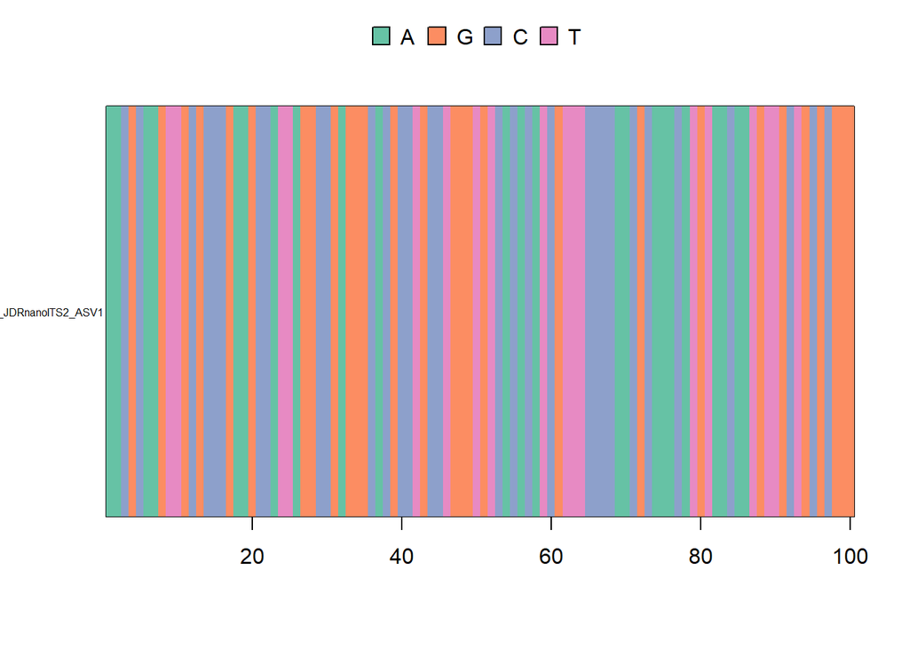

- based on comparing Gm alignment of blasted ITS from Gm genome (Geneious), this ASV is already forward oriented from the 5.8S to the LSU

#Create kmers

```r
myk.list <- list(13,14,15,16,17)
```

### Crops individually

```r
Ta.aln2 <- readDNAStringSet("./data/ASVs/Ta_ASVs_ITS2_aln_sub.fasta")
Ta.char <- paste(as.character(Ta.aln2$Ta_nanoITS2_ASV2[82:152]),
             as.character(Ta.aln2$Ta_nanoITS2_ASV2[154:159]), sep = "")
    #most abundant ASV from fITS7-ITS4ngs Illumina Run
    # also skipped blank pesent in 1 minor ASV to make kmers better
Ta.best <- list(Ta.char=Ta.char)
Ta.13to17 <- make_all_kmers(Ta.char, myk.list)
Ta.13to17 <- DNAStringSet(Ta.13to17)
#writeXStringSet(Ta.13to17, "./data/Ta_kmers13-17.fasta")
```

- Identified 315 candidate kmers for the Ta ITS2 region

```r
Hv.aln2 <- readDNAStringSet("./data/ASVs/Hv_ASVs_ITS2_aln.fasta")
Hv.char <- as.character(Hv.aln2$Hv_nanoITS2_ASV3[82:181])
    #most abundant ASV from fITS7-ITS4ngs Illumina Run
Hv.best <- list(Hv.char=Hv.char)
Hv.13to17 <- make_all_kmers(Hv.char, myk.list)
Hv.13to17 <- DNAStringSet(Hv.13to17)
#writeXStringSet(Hv.13to17, "./data/Hv_kmers13-17.fasta")
```

- Identified 430 candidate kmers for the Hv ITS2 region

```r
Zm.aln2 <- readDNAStringSet("./data/ASVs/Zm_ASVs_ITS2_aln.fasta")
Zm.char <- paste(as.character(Zm.aln2$Zm_JDRnanoITS2_ASV17[82:156]),
                 as.character(Zm.aln2$Zm_JDRnanoITS2_ASV17[159:183]), sep = "")
    #most abundant ASV from JDR Nano Illumina Run
    #also skipped blank pesent in 1 minor ASV to make kmers better
Zm.best <- list(Zm.char=Zm.char)
Zm.13to17 <- make_all_kmers(Zm.char, myk.list)
Zm.13to17 <- DNAStringSet(Zm.13to17)
#writeXStringSet(Zm.13to17, "./data/Zm_kmers13-17.fasta")
```

- Identified 430 candidate kmers for the Zm ITS2 region

```r
Gm.aln2 <- readDNAStringSet("./data/ASVs/Gm_ASVs_ITS2.fasta")
Gm.char <- as.character(Gm.aln2$Gm_JDRnanoITS2_ASV1[82:181])
    #only ASV from JDR nano Illumina Run (but if I remember, covered some 95% of seqs)
Gm.best <- list(Gm.char=Gm.char)
Gm.13to17 <- make_all_kmers(Gm.char, myk.list)
Gm.13to17 <- DNAStringSet(Gm.13to17)
#writeXStringSet(Gm.13to17, "./data/Gm_kmers13-17.fasta")
```

- Identified 430 candidate kmers for the Gm ITS2 region

### Crops all - representative sequence

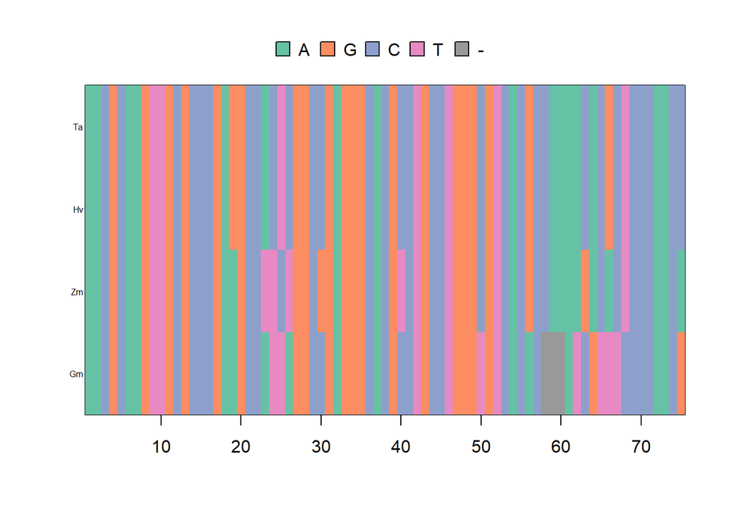

```r
sapply(list( Ta.aln2$Ta_nanoITS2_ASV2[c(82:152,154:182)],
             Hv.aln2$Hv_nanoITS2_ASV3[82:181],
             Zm.aln2$Zm_JDRnanoITS2_ASV17[c(82:156,159:183)],
             Gm.aln2$Gm_JDRnanoITS2_ASV1[82:181]) , as.character) -> out
names(out) <- c("Ta", "Hv", "Zm", "Gm")
fITS7_100bp <- DNAStringSet(out)
#writeXStringSet(fITS7_100bp, "./data/fITS7_100bp_allCrops.fasta")

all.aln2 <- seqinr::read.alignment("./data/fITS7_100bp_allCrops_aln.fasta",
                        format = "fasta")
all.bin2 <- ape::as.DNAbin(all.aln2)
all.wind2 <- all.bin2[, 1:75]  #perfect all 1:18, perfect except corn 27:49, perfect only Ta+Hv 1:75
ape::image.DNAbin(all.wind2, cex.lab = 0.50, col = dna.col)
```

```r
all.aln2 <- readDNAStringSet("./data/fITS7_100bp_allCrops_aln.fasta")
all.char <- as.character(all.aln2$Hv[1:75])
all.best <- list(all.char=all.char)
all.13to17 <- make_all_kmers(all.char, myk.list)
all.13to17 <- DNAStringSet(all.13to17)
#writeXStringSet(all.13to17, "./data/all_1-75bp_kmers13-17.fasta")


# for the subsets that are higher matches across all 4 crops
all2.char <- as.character(all.aln2$Hv[1:18])
all2.best <- list(all2.char=all2.char)
all2.13to17 <- make_all_kmers(all2.char, myk.list)
all2.13to17 <- DNAStringSet(all2.13to17)
#writeXStringSet(all2.13to17, "./data/all_1-18bp_kmers13-17.fasta")

all3.char <- as.character(all.aln2$Hv[27:49])
all3.best <- list(all3.char=all3.char)
all3.13to17 <- make_all_kmers(all3.char, myk.list)
all3.13to17 <- DNAStringSet(all3.13to17)
#writeXStringSet(all3.13to17, "./data/all_27-49bp_kmers13-17.fasta")
```

# Results of kmer BLAST query against Fungal DB

- Used 2021 UNITE db, but only fungi species hypothesis, not singletons, nor with all Euks
- two blast parms: -word_size 13 -perc_identity 100

```r
all.hits <- read.csv("./data/kmers/all_1-75bp_kmers13-17_hits.csv",
                 stringsAsFactors = TRUE, row.names = 1 )
Ta.hits <- read.csv("./data/kmers/Ta_kmers13-17_hits.csv",
                 stringsAsFactors = TRUE, row.names = 1 )
Hv.hits <- read.csv("./data/kmers/Hv_kmers13-17_hits.csv",
                 stringsAsFactors = TRUE, row.names = 1 )
Zm.hits <- read.csv("./data/kmers/Zm_kmers13-17_hits.csv",
                 stringsAsFactors = TRUE, row.names = 1 )
Gm.hits <- read.csv("./data/kmers/Gm_kmers13-17_hits.csv",
                 stringsAsFactors = TRUE, row.names = 1 )


all.nohits <- pullKmerSeqs(hits = all.hits, kmer.stringset = all.13to17)
Ta.nohits <- pullKmerSeqs(hits = Ta.hits, kmer.stringset = Ta.13to17)
Hv.nohits <- pullKmerSeqs(hits = Hv.hits, kmer.stringset = Hv.13to17)
Zm.nohits <- pullKmerSeqs(hits = Zm.hits, kmer.stringset = Zm.13to17)
Gm.nohits <- pullKmerSeqs(hits = Gm.hits, kmer.stringset = Gm.13to17)
#hist(width(Gm.nohits))
```

- too many no-fungal-hits results. need to subset somehow. can either 1) focus on regions contingent across all 4 crops (redo blast or see if kmers in common across the 4 separate batches), 2) focus on the kmers that block the most sequences/ASVs from sequencing runs

```r
all2.hits <- read.csv("./data/kmers/all_1-18bp_kmers13-17_hits.csv",
                 stringsAsFactors = TRUE, row.names = 1 )
all3.hits <- read.csv("./data/kmers/all_27-49bp_kmers13-17_hits.csv",
                 stringsAsFactors = TRUE, row.names = 1 )
all2.nohits <- pullKmerSeqs(hits = all2.hits, kmer.stringset = all2.13to17)
all3.nohits <- pullKmerSeqs(hits = all3.hits, kmer.stringset = all3.13to17)

#write.csv(all2.nohits, "./data/kmers/all_1-18bp_kmers13-17_nofungalhits.csv")  #3 remaining hits
#write.csv(all3.nohits, "./data/kmers/all_27-49bp_kmers13-17_nofungalhits.csv")  #8 remaining hits
```

- fed the remaining kmers from these two batches into the PNABio ‘PNA Tool’ to get design specifications. All of the kmers in the 27-49kmer stretch have too much Purine/G content. 2/3 of the kmers in the -18bp stretch have good design specs and reasonable Tm’s (75.1 and 78.3 degC at 4uM).
- Comparing to Nano Run’s ASVs:
  - Of the Ta ASVs from the Sept Nano Run – ASV134, ASV146, ASV200 are the only ones that would be missed (and an addition two from Jenny’s nano run from 2020- ASV117 & ASV209)
  - Of the Zm ASVs from Jenny’s 2020 nano run, none would be missed.
  - Of the Hv ASVs from the Sept Nano Run – (only 1 ASV) none are missed. Also none would be missed from the May 2022 Nano run, where different primer batches were used.
  - Of the Gm ASVs from Jenny’s 2020 nano run, (only 1 ASV) none would be missed.
- Of the blasted genome ITS sequences (aligned).
  - Hv 75.8% of seqs covered.
  - Gm 98.5% of seqs covered.
  - Zm 94.8% of seqs covered.
  - Ta 78.2% of seqs covered.

# Proposed PNAs

```r
all2.nohits <- read.csv("./data/kmers/all_1-18bp_kmers13-17_nofungalhits.csv",
                 stringsAsFactors = TRUE, row.names = 1)
all2.nohits[1,]
```

```
##             kmer_seq Length_bp   Tm Purine_Perc GC_content Design
## kmer_5 CAAGTTGCGCCCG        13 75.1        46.2       69.2   Good
##        Self_complementarity complementarity_notes            RC
## kmer_5                 some         caaGttgCGCCCG CGGGCGCAACTTG
```

```r
all2.nohits[3,]
```

```
##               kmer_seq Length_bp   Tm Purine_Perc GC_content Design
## kmer_11 CAAGTTGCGCCCGA        14 78.3          50       64.3   Good
##         Self_complementarity complementarity_notes             RC
## kmer_11                 some        caaGttgCGCCCGA TCGGGCGCAACTTG
```

# Compare Proposed PNAs to Nano Illumina Run results

```r
# load in wheat and barley nano Illumina run phyloseq object
load("../cropPrimer/data/wheatBarley_ps_ids.RData")
ps
```

```
## phyloseq-class experiment-level object
## otu_table()   OTU Table:         [ 234 taxa and 37 samples ]
## sample_data() Sample Data:       [ 37 samples by 8 sample variables ]
## tax_table()   Taxonomy Table:    [ 234 taxa by 7 taxonomic ranks ]
## refseq()      DNAStringSet:      [ 234 reference sequences ]
```

```r
lowConf.ncbi <- read.csv("../cropPrimer/data/wheatBarley_lowConfASVs.csv",
                         row.names = 1, stringsAsFactors = TRUE)
notFungiASVs <- droplevels(lowConf.ncbi$ASV[lowConf.ncbi$Problematic=="yes"])
plantASVs <- droplevels(lowConf.ncbi$ASV[lowConf.ncbi$NCBI.Blast.Group=="Plant"])

SbyS_all <- ps@otu_table@.Data
totReads <- sum(colSums(ps@otu_table))
plantASVsums <- colSums(SbyS_all[,colnames(SbyS_all) %in% plantASVs])

propASVPlantReads <- c(plantASVsums/totReads); round(propASVPlantReads,6)
```

```
##     ASV2     ASV3     ASV5     ASV9    ASV10    ASV16   ASV117   ASV130
## 0.098430 0.093204 0.080327 0.040185 0.027867 0.012307 0.000106 0.000070
##   ASV133   ASV134   ASV137   ASV139   ASV146   ASV153   ASV173   ASV199
## 0.000066 0.000066 0.000063 0.000056 0.000053 0.000043 0.000030 0.000020
##   ASV200   ASV201   ASV202   ASV207   ASV226   ASV227
## 0.000020 0.000020 0.000020 0.000017 0.000010 0.000010
```

```r
propAllPlantReads <- sum(propASVPlantReads); propAllPlantReads
```

```
## [1] 0.3529903
```

```r
ASVsNotCovered <- c('ASV134', 'ASV146', 'ASV200')

# sum of the proportion of sequencing reads not covered by the potential PNA
notCovered <- sum(propASVPlantReads[names(propASVPlantReads) %in% ASVsNotCovered])
notCovered
```

```
## [1] 0.0001392545
```

```r
propAllPlantReads/notCovered
```

```
## [1] 2534.857
```

- So in summary, 35.299% of all reads from nano Illumina Run in September were plant in origin (most of these in triticum, and counterbalanced by the lack of plant contamination in the debris positive control samples).
- The proposed PNAs would reduce this plant contamination down to 0.014% of the total run, or in other words a >2500-fold reduction in plant contamination.